# Rozkłady mieszane

Jakub Ignatik

12 kwietnia 2018

### Funkcja “rmix”

Na początku załaduję biblioteki i wprowadzę funkcję rmix, potrzebną przy tworzeniu rozkładów mieszanych.

```r
library(ggplot2)
library(dplyr)
library(tidyr)
library(tseries)

rmix <- function(n, family_1, par_1, family_2, par_2, p){
    if (family_1 == "norm"){
      mean_f1 = par_1[1]
      sd_f1 = par_1[2]
      rozklad1 <- rnorm(n, mean_f1, sd_f1)
    }
    else if (family_1 == "t"){
      df_f1 = par_1
      rozklad1 <- rt(n, df_f1)
    }
    else if (family_1 == "binom"){
      size_f1 = par_1[1]
      prob_f1 = par_1[2]
      rozklad1 <- rbinom(n, size_f1, prob_f1)
    }
    else{
      lambda_f1 = par_1
      rozklad1 <- rpois(n, lambda_f1)
    }

    if (family_2 == "norm"){
      mean_f2 = par_2[1]
      sd_f2 = par_2[2]
      rozklad2 <- rnorm(n, mean_f2, sd_f2)
    }
    else if (family_2 == "t"){
      df_f2 = par_2
      rozklad2 <- rt(n, df_f2)
    }
    else if (family_1 == "binom"){
      size_f2 = par_2[1]
      prob_f2 = par_2[2]
      rozklad2 <- rbinom(n, size_f2, prob_f2)
    }
    else{
      lambda_f2 = par_2
      rozklad2 <- rpois(n, lambda_f2)
    }

  index <- sample(c(1,2), size = n, replace = TRUE, prob = c(p, 1-p))
  jedynki <- sum(index == 1)
  dwojki <- sum(index == 2)
  rozklad1 <- sample(rozklad1, jedynki, replace = FALSE)
  rozklad2 <- sample(rozklad2, dwojki, replace = TRUE)
  wektor <- c(rozklad1, rozklad2)
  #print(wektor)
}
```

## Wpływ prawdopodobieństwa

Na początku wprowadzę wybrane przeze mnie parametry rozkładów normalnych oraz stworzę ramkę danych dla kombinacji tych właśnie parametrów, poziomu istotności i długości danych.

```r
#############################################################################################
                                    #PRAWDOBODOBIEŃSTWO#
#############################################################################################

set.seed(111)
#ilość symulacji
N <- 1

#wartości oczekiwane family_1
mean_f1 <- 0
#odchylenia standardowe family_1
sd_f1 <- 1

#wartości oczekiwane family_2
mean_f2 <- 3
#odchylenia standardowe family_2
sd_f2 <- 2

#prawdopodobieństwa wylosowania danych z rozkładu family_1
prob <- seq(0.1,0.9, by=.1)
#poziom istotności
alpha <- 0.05
#długości próby
sample_l <- seq(10,200,by=10)

params <- expand.grid(mean_f1, sd_f1, mean_f2, sd_f2, prob, sample_l)
names(params) <- c("mean_f1", "sd_f1", "mean_f2", "sd_f2", "prob", "length")
```

Następnie obliczam moce testów (Shapiro-WIlka, Jarque-Bera oraz Kołmogorowa) i dodaję je do wcześniej utworzonej ramki danych.

```r
powers_sw <- sapply(1:nrow(params), function(p){
  mean_f1 <- params[p, 1]
  sd_f1 <- params[p, 2]
  mean_f2 <- params[p, 3]
  sd_f2 <- params[p, 4]
  prob <- params[p, 5]
  l <- params[p, 6]
  p_sim <-sapply(rep(sd_f1, N), function(x){
    rmixx <- rmix(l, "norm", c(mean_f1,sd_f1), "norm", c(mean_f2,sd_f2), prob)
    shapiro.test(rmixx)$p.value
  })
  mean(p_sim < alpha)
})
power_sw <- bind_cols(params, power = powers_sw)

powers_jb <- sapply(1:nrow(params), function(p){
  mean_f1 <- params[p, 1]
  sd_f1 <- params[p, 2]
  mean_f2 <- params[p, 3]
  sd_f2 <- params[p, 4]
  prob <- params[p, 5]
  l <- params[p, 6]
  p_sim <-sapply(rep(sd_f1, N), function(x){
    rmixx <- rmix(l, "norm", c(mean_f1,sd_f1), "norm", c(mean_f2,sd_f2), prob)
    jarque.bera.test(rmixx)$p.value
  })
  mean(p_sim < alpha)
})
power_jb <- bind_cols(params, power = powers_jb)

powers_ks <- sapply(1:nrow(params), function(p){
  mean_f1 <- params[p, 1]
  sd_f1 <- params[p, 2]
  mean_f2 <- params[p, 3]
  sd_f2 <- params[p, 4]
  prob <- params[p, 5]
  l <- params[p, 6]
  p_sim <-sapply(rep(sd_f1, N), function(x){
    rmixx <- rmix(l, "norm", c(mean_f1,sd_f1), "norm", c(mean_f2,sd_f2), prob)
    ks.test(rmixx,pnorm)$p.value
  })
  mean(p_sim < alpha)
})
power_ks <- bind_cols(params, power = powers_ks)
```

Teraz tworzę wykresy dla wszystkich testów.

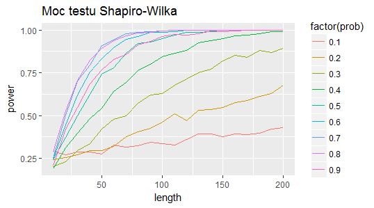

```r
invisible(power_sw %>% ggplot(aes(x = length,
                        y = power,
                        col = factor(prob))) +
  geom_line() + ggtitle("Moc testu Shapiro-Wilka"))
knitr::include_graphics("Shapiro_p.png")
```

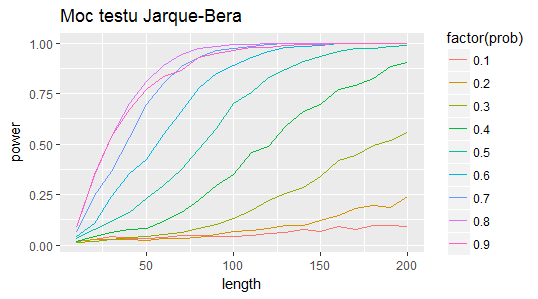

```r
invisible(power_jb %>% ggplot(aes(x = length,
                        y = power,
                        col = factor(prob))) +
  geom_line() + ggtitle("Moc testu Jarque-Bera"))
knitr::include_graphics("jarque_p.png")
```

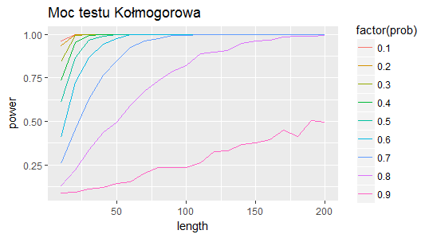

```r
invisible(power_ks %>% ggplot(aes(x = length,
                        y = power,
                        col = factor(prob))) +
  geom_line() + ggtitle("Moc testu Kołmogorowa"))
knitr::include_graphics("Kolmogorow_p.png")
```

## Wpływ parametrów par_1

# Średnia par_1

W każdym z poniższych przypadków kod wygląda tak samo jak w przypadku badania wpływu pradopodobieństwa, z tą różnicą, że inne są parametry. Dla przypadków badających wpływ par_1 oraz par_2 określiłem prawdopodobieństwo p na poziomie 0,6.

```r
#############################################################################################
                                           #PAR_1#
#############################################################################################

##########################################  MEAN  ###########################################

set.seed(111)
#ilość symulacji
N <- 1

#wartości oczekiwane family_1
mean_f1 <- seq(1,10,by=1)
#odchylenia standardowe family_1
sd_f1 <- 2

#wartości oczekiwane family_2
mean_f2 <- 0
#odchylenia standardowe family_2
sd_f2 <- 1

#prawdopodobieństwa wylosowania danych z rozkładu family_1
prob <- 0.6
#poziom istotności
alpha <- 0.05
#długości próby
sample_l <- seq(10,200,by=10)

params <- expand.grid(mean_f1, sd_f1, mean_f2, sd_f2, prob, sample_l)
names(params) <- c("mean_f1", "sd_f1", "mean_f2", "sd_f2", "prob", "length")
```

Obliczam moce wszystkich testów i dodaję je do wcześniej utworzonej ramki danych.

```r
powers_sw <- sapply(1:nrow(params), function(p){
  mean_f1 <- params[p, 1]
  sd_f1 <- params[p, 2]
  mean_f2 <- params[p, 3]
  sd_f2 <- params[p, 4]
  prob <- params[p, 5]
  l <- params[p, 6]
  p_sim <-sapply(rep(sd_f1, N), function(x){
    rmixx <- rmix(l, "norm", c(mean_f1,sd_f1), "norm", c(mean_f2,sd_f2), prob)
    shapiro.test(rmixx)$p.value
  })
  mean(p_sim < alpha)
})
power_sw <- bind_cols(params, power = powers_sw)

powers_jb <- sapply(1:nrow(params), function(p){
  mean_f1 <- params[p, 1]
  sd_f1 <- params[p, 2]
  mean_f2 <- params[p, 3]
  sd_f2 <- params[p, 4]
  prob <- params[p, 5]
  l <- params[p, 6]
  p_sim <-sapply(rep(sd_f1, N), function(x){
    rmixx <- rmix(l, "norm", c(mean_f1,sd_f1), "norm", c(mean_f2,sd_f2), prob)
    jarque.bera.test(rmixx)$p.value
  })
  mean(p_sim < alpha)
})
power_jb <- bind_cols(params, power = powers_jb)

powers_ks <- sapply(1:nrow(params), function(p){
  mean_f1 <- params[p, 1]
  sd_f1 <- params[p, 2]
  mean_f2 <- params[p, 3]
  sd_f2 <- params[p, 4]
  prob <- params[p, 5]
  l <- params[p, 6]
  p_sim <-sapply(rep(sd_f1, N), function(x){
    rmixx <- rmix(l, "norm", c(mean_f1,sd_f1), "norm", c(mean_f2,sd_f2), prob)
    ks.test(rmixx,pnorm)$p.value
  })
  mean(p_sim < alpha)
})
power_ks <- bind_cols(params, power = powers_ks)
```

Teraz tworzę wykresy dla testów

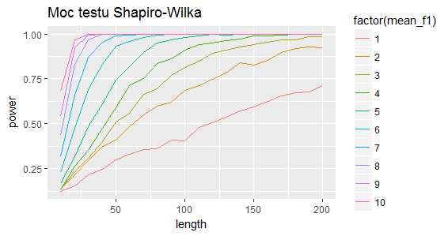

```r
invisible(power_sw %>% ggplot(aes(x = length,
                        y = power,
                        col = factor(mean_f1))) +
  geom_line() + ggtitle("Moc testu Shapiro-Wilka"))
knitr::include_graphics("Shapiro_meanf1.png")
```

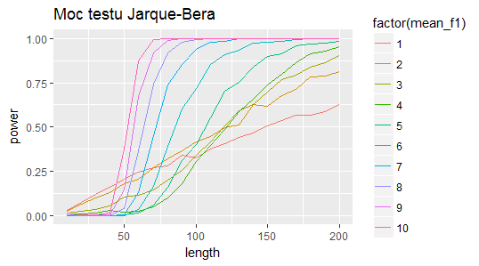

```r
invisible(power_jb %>% ggplot(aes(x = length,
                        y = power,
                        col = factor(mean_f1))) +
  geom_line() + ggtitle("Moc testu Jarque-Bera"))
knitr::include_graphics("Jarque_meanf1.png")
```

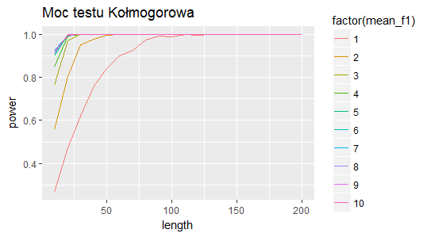

```r
invisible(power_ks %>% ggplot(aes(x = length,
                        y = power,
                        col = factor(mean_f1))) +
  geom_line() + ggtitle("Moc testu Kołmogorowa"))
knitr::include_graphics("Kolmogorow_meanf1.png")
```

# Odchylenie standardowe par_1

Rozważę teraz wpływ odchylenia standardowego par_1.

```r
##########################################  SD  #############################################

set.seed(111)
#ilość symulacji
N <- 1

#wartości oczekiwane family_1
mean_f1 <- 5
#odchylenia standardowe family_1
sd_f1 <- seq(1,10,by=1)

#wartości oczekiwane family_2
mean_f2 <- 0
#odchylenia standardowe family_2
sd_f2 <- 1

#prawdopodobieństwa wylosowania danych z rozkładu family_1
prob <- 0.6
#poziom istotności
alpha <- 0.05
#długości próby
sample_l <- seq(10,200,by=10)

params <- expand.grid(mean_f1, sd_f1, mean_f2, sd_f2, prob, sample_l)
names(params) <- c("mean_f1", "sd_f1", "mean_f2", "sd_f2", "prob", "length")
```

Następnie obliczam moce wszystkich testów i dodaję je do wcześniej utworzonej ramki danych.

```r
powers_sw <- sapply(1:nrow(params), function(p){
  mean_f1 <- params[p, 1]
  sd_f1 <- params[p, 2]
  mean_f2 <- params[p, 3]
  sd_f2 <- params[p, 4]
  prob <- params[p, 5]
  l <- params[p, 6]
  p_sim <-sapply(rep(sd_f1, N), function(x){
    rmixx <- rmix(l, "norm", c(mean_f1,sd_f1), "norm", c(mean_f2,sd_f2), prob)
    shapiro.test(rmixx)$p.value
  })
  mean(p_sim < alpha)
})
power_sw <- bind_cols(params, power = powers_sw)

powers_jb <- sapply(1:nrow(params), function(p){
  mean_f1 <- params[p, 1]
  sd_f1 <- params[p, 2]
  mean_f2 <- params[p, 3]
  sd_f2 <- params[p, 4]
  prob <- params[p, 5]
  l <- params[p, 6]
  p_sim <-sapply(rep(sd_f1, N), function(x){
    rmixx <- rmix(l, "norm", c(mean_f1,sd_f1), "norm", c(mean_f2,sd_f2), prob)
    jarque.bera.test(rmixx)$p.value
  })
  mean(p_sim < alpha)
})
power_jb <- bind_cols(params, power = powers_jb)

powers_ks <- sapply(1:nrow(params), function(p){
  mean_f1 <- params[p, 1]
  sd_f1 <- params[p, 2]
  mean_f2 <- params[p, 3]
  sd_f2 <- params[p, 4]
  prob <- params[p, 5]
  l <- params[p, 6]
  p_sim <-sapply(rep(sd_f1, N), function(x){
    rmixx <- rmix(l, "norm", c(mean_f1,sd_f1), "norm", c(mean_f2,sd_f2), prob)
    ks.test(rmixx,pnorm)$p.value
  })
  mean(p_sim < alpha)
})
power_jb <- bind_cols(params, power = powers_ks)
```

Teraz tworzę wykresy dla testów

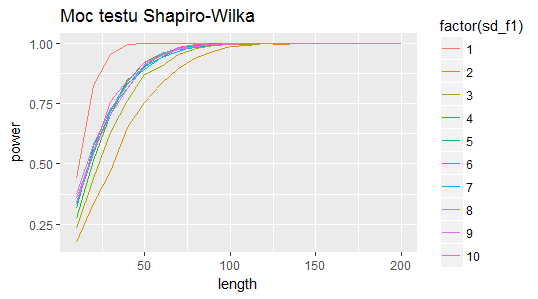

```r
invisible(power_sw %>% ggplot(aes(x = length,
                        y = power,
                        col = factor(sd_f1))) +
  geom_line() + ggtitle("Moc testu Shapiro-Wilka"))
knitr::include_graphics("Shapiro_sdf1.png")
```

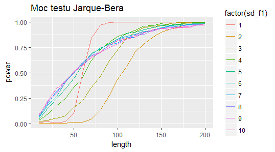

```r
invisible(power_jb %>% ggplot(aes(x = length,
                        y = power,
                        col = factor(sd_f1))) +
  geom_line() + ggtitle("Moc testu Jarque-Bera"))
knitr::include_graphics("Jarque_sdf1.png")
```

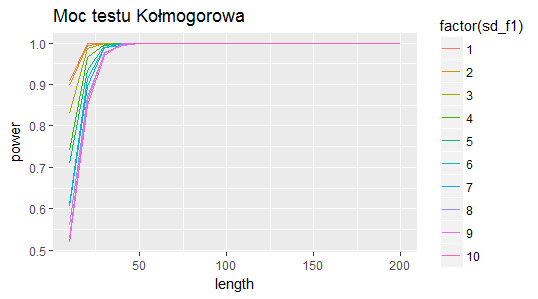

```r
invisible(power_ks %>% ggplot(aes(x = length,
                        y = power,
                        col = factor(sd_f1))) +
  geom_line() + ggtitle("Moc testu Kołmogorowa"))
knitr::include_graphics("Kolmogorow_sdf1.png")
```

**Liczba obserwacji:** Jak widać, we wszystkich testach wraz ze wzrostem liczby obserwacji rośnie moc testu. W każdym z testów wzrost ten wygląda podobnie (w teście Kołmogorowa linia jest znacznie bardziej pionowa), z wyjątkiem małych wartości odchyleń w teście Jarque-Bera, gdzie wygląda to podobnie jak przy średniej (dla małych odchyleń niewielki wzrost liczby obserwacji znacząco wpływa na moc testu).  
**Odchylenie standardowe:** Sytuacja wygląda najprościej w teście Kołmogorowa. Wzrost odchylenia standardowego przekłada się na spadek mocy testu, jednak już w próbce równej około 40 przez wszystkie odchylenia zostaje osiągnięta moc równa jeden. W przypadku tego testu nie potwierdziła się moja hipoteza. Można natomiast powiedzieć, że trafnie przewidziałem wynik w przypadku dwóch pozostałych testów, choć nie do końca. Na początku (do odchylenia równego 2) moc testu spada, a by potem wzrosnąć, a powyżej liczby 4-5 nie widać większych różnic (przy odchyleniu równym jeden najszybciej zostaje osiągnięta moc równa jeden: w Shapiro-Wilka dla 40 obserwacji, w Jarque-Bera dla 90, w obu sporo szybciej niż dla pozostałych odchyleń, zwłaszcza przy teście Jarque-Bera). Oznacza to, że dla wykresów “szczupłych”, z małym odchyleniem, moc testu jest największa (w teście Jarque-Bera widać to dopiero powyżej 60 obserwacji), a na kolejnym miejscu plasują się rozkłady z odchyleniem dość sporym (przy założonych wyżej danych, gdzie wartości średnie są od siebie oddalone).  
**Ogólne uwagi:** Tym razem test Kołmogorowa również okazał się najsilniejszy. Cechuje go także odstępstwo od pozostałych testów pod względem wyników, gdyż coraz wyższe wartości odchyleń powodują spadek, a nie wzrost mocy testu. Najsłabiej ponownie wypadł test Jarque-Bera, gdzie na osi Y widać wartość 0, co świadczy o małej początkowej mocy. Później też nie jest lepiej - kiedy test Shapiro-Wilka osiąga przy długości równej 125 moc równą jeden dla wszystkich odchyleń, test Jarque-Bera ma taką sytuację tylko w przypadku jedynki.

## Wpływ parametrów par_2

# Średnia par_2

Dane z drugiego rozkładu są brane z prawdopodobieństwem równym 40%, więc można oczekiwać niewielkich różnic w porównaniu z badaniem wpływu parametrów par_1.

```r
#############################################################################################
                                           #PAR_2#
#############################################################################################

##########################################  MEAN  ###########################################

set.seed(111)
#ilość symulacji
N <- 1

#wartości oczekiwane family_1
mean_f1 <- 0
#odchylenia standardowe family_1
sd_f1 <- 1

#wartości oczekiwane family_2
mean_f2 <- seq(1,10,by=1)
#odchylenia standardowe family_2
sd_f2 <- 2

#prawdopodobieństwa wylosowania danych z rozkładu family_1
prob <- 0.6
#poziom istotności
alpha <- 0.05
#długości próby
sample_l <- seq(10,200,by=10)

params <- expand.grid(mean_f1, sd_f1, mean_f2, sd_f2, prob, sample_l)
names(params) <- c("mean_f1", "sd_f1", "mean_f2", "sd_f2", "prob", "length")
```

Następnie obliczam moce testów i dodaję je do wcześniej utworzonej ramki danych.

```r
powers_sw <- sapply(1:nrow(params), function(p){
  mean_f1 <- params[p, 1]
  sd_f1 <- params[p, 2]
  mean_f2 <- params[p, 3]
  sd_f2 <- params[p, 4]
  prob <- params[p, 5]
  l <- params[p, 6]
  p_sim <-sapply(rep(sd_f1, N), function(x){
    rmixx <- rmix(l, "norm", c(mean_f1,sd_f1), "norm", c(mean_f2,sd_f2), prob)
    shapiro.test(rmixx)$p.value
  })
  mean(p_sim < alpha)
})
power_sw <- bind_cols(params, power = powers_sw)

powers_jb <- sapply(1:nrow(params), function(p){
  mean_f1 <- params[p, 1]
  sd_f1 <- params[p, 2]
  mean_f2 <- params[p, 3]
  sd_f2 <- params[p, 4]
  prob <- params[p, 5]
  l <- params[p, 6]
  p_sim <-sapply(rep(sd_f1, N), function(x){
    rmixx <- rmix(l, "norm", c(mean_f1,sd_f1), "norm", c(mean_f2,sd_f2), prob)
    jarque.bera.test(rmixx)$p.value
  })
  mean(p_sim < alpha)
})
power_jb <- bind_cols(params, power = powers_jb)

powers_ks <- sapply(1:nrow(params), function(p){
  mean_f1 <- params[p, 1]
  sd_f1 <- params[p, 2]
  mean_f2 <- params[p, 3]
  sd_f2 <- params[p, 4]
  prob <- params[p, 5]
  l <- params[p, 6]
  p_sim <-sapply(rep(sd_f1, N), function(x){
    rmixx <- rmix(l, "norm", c(mean_f1,sd_f1), "norm", c(mean_f2,sd_f2), prob)
    ks.test(rmixx,pnorm)$p.value
  })
  mean(p_sim < alpha)
})
power_ks <- bind_cols(params, power = powers_ks)
```

Teraz tworzę wykresy dla testów.

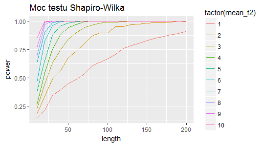

```r
invisible(power_sw %>% ggplot(aes(x = length,
                        y = power,
                        col = factor(mean_f2))) +
  geom_line() + ggtitle("Moc testu Shapiro-Wilka"))
knitr::include_graphics("Shapiro_meanf2.png")
```

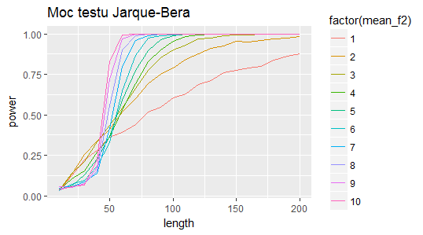

```r
invisible(power_jb %>% ggplot(aes(x = length,
                        y = power,
                        col = factor(mean_f2))) +
  geom_line() + ggtitle("Moc testu Jarque-Bera"))
knitr::include_graphics("Jarque_meanf2.png")
```

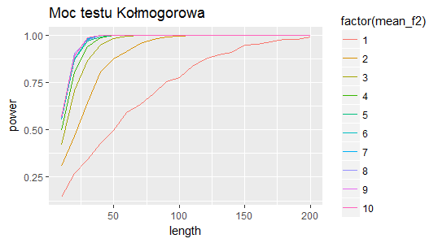

```r
invisible(power_ks %>% ggplot(aes(x = length,
                        y = power,
                        col = factor(mean_f2))) +
  geom_line() + ggtitle("Moc testu Kołmogorowa"))
knitr::include_graphics("Kolmogorow_meanf2.png")
```

**Liczba obserwacji:** Sytuacja jest podobna do średniej z par_1, we wszystkich testach wraz ze wzrostem liczby obserwacji rośnie moc testu. Największy wpływ liczba obserwacji ma przy większych średnich, gdzie wydłużenie próbki o małą ilość wpływa znacząco na podwyższenie mocy testu. Dla coraz wyższych średnich wpływ jest ten coraz bardziej widoczny. Wyjątek stanowi test Kołmogorowa, gdzie od średniej równej 5 nie widać różnicy w nachyleniu linii. Warto wyróżnić też test Jarque-Bera, gdzie, jak przy średniej z par_1, zmiana długości próby wpływa szczególnie mocno na moc próby w dość wąskim przedziale. Zwiększenie obserwacji z 40 do 75 podnosi moc testu o przynajmniej 0.5 (licząc od średniej równej 4, choć te niższe, poza jedynką, też sporo przyśpieszają).  
**Średnia:** W przypadku wszystkich testów wzrost średniej z drugiej pary parametrów przełożył się na wzrost mocy testu, podobnie jak w par_1. Ponownie występuje pewna anomalia przy teście Jarque-Bera. Przy małej ilości próby sytuacja nie przypomina tej w innych testach. Większa średnia wpływa wtedy na obniżenie mocy testu. Sytuacja wraca do normy w okolicy długości próby równej 50, kiedy to małe wartości średniej z ich wolniejszym wzrostem zostają prześcignięte przez pozostałe średnie, z szybszym wzrostem.  
**Ogólne uwagi:** Test Kołmogorowa i w tej parze parametrów okazał się najsilniejszy - dosyć spory przeskok między najmniejszą średnią a wartością tej drugiej średniej (około 0,15) i szybki wzrost. Najsłabiej wypadł test Jarque-Bera, gdzie na osi Y widać wartość 0, co świadczy o małej początkowej mocy. Mimo początkowej sporej mocy dla małych średnich wypada on i tak gorzej w porównaniu z małymi wartościami w teście Shapiro-Wilka. W przypadku wszystkich wartości moc równa jeden jest osiągana później(dla średniej 10 o długość równą 40, dla średniej równej 6 aż o 55, ale już dla średniej 5 o 40, czyli dla mniejszych średnich różnica jest mniejsza). Oba testy jednak i tak pozostawia w tyle test Kołmogorowa.

# Odchylenie standardowe par_2

Rozważę teraz wpływ odchylenia standardowego par_2.

```r
##########################################  SD  #############################################

set.seed(111)
#ilość symulacji
N <- 1

#wartości oczekiwane family_1
mean_f1 <- 0
#odchylenia standardowe family_1
sd_f1 <- 1

#wartości oczekiwane family_2
mean_f2 <- 5
#odchylenia standardowe family_2
sd_f2 <- seq(1,10,by=1)

#prawdopodobieństwa wylosowania danych z rozkładu family_1
prob <- 0.6
#poziom istotności
alpha <- 0.05
#długości próby
sample_l <- seq(10,200,by=10)

params <- expand.grid(mean_f1, sd_f1, mean_f2, sd_f2, prob, sample_l)
names(params) <- c("mean_f1", "sd_f1", "mean_f2", "sd_f2", "prob", "length")
```

Następnie obliczam moce testów i dodaję je do wcześniej utworzonej ramki danych.

```r
powers_sw <- sapply(1:nrow(params), function(p){
  mean_f1 <- params[p, 1]
  sd_f1 <- params[p, 2]
  mean_f2 <- params[p, 3]
  sd_f2 <- params[p, 4]
  prob <- params[p, 5]
  l <- params[p, 6]
  p_sim <-sapply(rep(sd_f1, N), function(x){
    rmixx <- rmix(l, "norm", c(mean_f1,sd_f1), "norm", c(mean_f2,sd_f2), prob)
    shapiro.test(rmixx)$p.value
  })
  mean(p_sim < alpha)
})
power_sw <- bind_cols(params, power = powers_sw)

powers_jb <- sapply(1:nrow(params), function(p){
  mean_f1 <- params[p, 1]
  sd_f1 <- params[p, 2]
  mean_f2 <- params[p, 3]
  sd_f2 <- params[p, 4]
  prob <- params[p, 5]
  l <- params[p, 6]
  p_sim <-sapply(rep(sd_f1, N), function(x){
    rmixx <- rmix(l, "norm", c(mean_f1,sd_f1), "norm", c(mean_f2,sd_f2), prob)
    jarque.bera.test(rmixx)$p.value
  })
  mean(p_sim < alpha)
})
power_jb <- bind_cols(params, power = powers_jb)

powers_ks <- sapply(1:nrow(params), function(p){
  mean_f1 <- params[p, 1]
  sd_f1 <- params[p, 2]
  mean_f2 <- params[p, 3]
  sd_f2 <- params[p, 4]
  prob <- params[p, 5]
  l <- params[p, 6]
  p_sim <-sapply(rep(sd_f1, N), function(x){
    rmixx <- rmix(l, "norm", c(mean_f1,sd_f1), "norm", c(mean_f2,sd_f2), prob)
    ks.test(rmixx,pnorm)$p.value
  })
  mean(p_sim < alpha)
})
power_ks <- bind_cols(params, power = powers_ks)
```

Teraz tworzę wykresy dla testów.

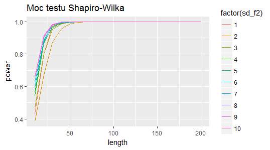

```r
invisible(power_sw %>% ggplot(aes(x = length,
                        y = power,
                        col = factor(sd_f2))) +
  geom_line() + ggtitle("Moc testu Shapiro-Wilka"))
knitr::include_graphics("Shapiro_sdf2.png")
```

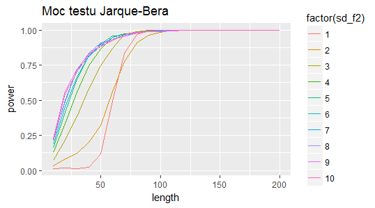

```r
invisible(power_jb %>% ggplot(aes(x = length,
                        y = power,
                        col = factor(sd_f2))) +
  geom_line() + ggtitle("Moc testu Jarque-Bera"))
knitr::include_graphics("Jarque_sdf2.png")
```

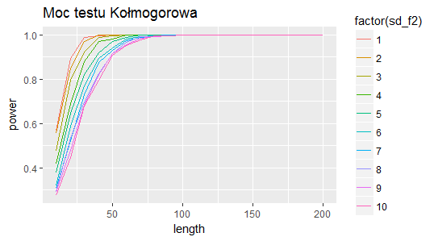

```r
invisible(power_ks %>% ggplot(aes(x = length,
                        y = power,
                        col = factor(sd_f2))) +
  geom_line() + ggtitle("Moc testu Kołmogorowa"))
knitr::include_graphics("Kolmogorow_sdf2.png")
```

**Liczba obserwacji:** We wszystkich testach wraz ze wzrostem liczby obserwacji rośnie moc testu. Tym razem długość próby ma największy wpływ w teście Shapiro-Wilka, gdzie wykresy są najbardziej zbliżone do pionu.  
**Odchylenie standardowe:** Sytuacja wygląda najprościej w teście Kołmogorowa. Wzrost odchylenia standardowego przekłada się na spadek mocy testu, jednak już w próbce równej około 100 przez wszystkie odchylenia zostaje osiągnięta moc równa jeden. W przypadku tego testu nie potwierdziła się moja hipoteza, ale trafnie przewidziałem wynik w przypadku dwóch pozostałych testów, choć nie do końca. W teście Shapiro-Wilka na początku (do odchylenia równego 2) moc testu spada, aby potem wzrosnąć. W teście Jarque-Bera od liczby obserwacji równej 50 zmienia się nieco układ odchyleń standardowych. Zaczyna gwałtownie rosnąć moc dla odchylenia równego 1 (przy liczbie obserwacji równej 70 przegania odchylenie równe 2, aby następnie osiągnąć moc równą 1 przed niektórymi wyższymi odchyleniami), a odchylenia 4 i 5 (trochę później także 3) wysuwają się na prowadzenie, aby potem zrównać się z resztą wysokich odchyleń. Jeśli chodzi o poszczególne odchylenia, powyżej liczby 4 (test Shapiro-Wilka), 8 (test Jarque-Bera) nie widać większych różnic, czyli zwiększenie odchylenia nie przekłada się na wzrost mocy testu. Natomiast wykresy szczupłe, z małym odchyleniem, są szczególnie mocne w wybranych przedziałach (50-70, dla odchylenia równego 4-5, to dotyczy jednak wyłącznie testu Jarque-Bera).  
**Ogólne uwagi:** Tym razem test Kołmogorowa nie okazał się najsilniejszy. Jego pozycję zajął test Shapiro-Wilka, który razem z testem Jarque-Bera potwierdza moją hipotezę. Nie zmieniło się ostatnie miejsce na podium - najsłabiej ponownie wypadł test Jarque-Bera, gdzie na osi Y widać wartość 0, co świadczy o małej początkowej mocy. Później też nie jest lepiej, mimo podobnej dynamiki w porównaniu z pozostałymi testami.

### Zakończenie (część I)

**Średnia par_1 a średnia par_2:**  
*Testy Shapiro-Wilka oraz Jarque-Bera dla par_2*:  
-Wykresy są “ściśnięte”, co oznacza, że testy dla średniej par_2 bardziej reagują na zwiększenie długości próby, szybciej osiąga się większą moc testu niż przy par_1 dla takich samych średnich  
*Test Kołmogorowa dla par_2*:  
-Sytuacja odwrotna, wykres przesunął się w prawo względem par_1, mniejsza moc testu  
*Wniosek*: Żeby zwiększyć moc testu przy jak najmniejszej dodanej liczbie obserwacji, należy dodawać obserwacje z rozkładu drugiego (1-p, gdy p>0,5) (w przypadku testów Shapiro-Wilka i Jarque-Bera, w teście Kołmogorowa trzeba postąpić odwrotnie).

**Odchylenie standardowe par_1 a odchylenie standardowe par_2:**  
*Testy Shapiro-Wilka oraz Jarque-Bera dla par_2*:  
-Wykresy są “ściśnięte”, co oznacza, że testy dla odchylenia par_2 bardziej reagują na zwiększenie długości próby, szybciej osiąga się większą moc testu niż przy par_1 dla takich samych średnich  
-Zniknęła dominująca pozycja odchylenia równego jeden: w teście Shapiro-Wilka linia przesunęła się w dół, a reszta powędrowała do góry; w teście Jarque-Bera linia pozostała na miejscu, ale reszta powędrowała do góry  
-W teście Jarque-Bera słabnie pozycja mniejszych odchyleń standardowych, prześcigają one te wyższe na przedziale 50-75, a nie na przedziale 70-200+. *Test Kołmogorowa dla par_2*:  
-Wykres przesunął się w prawo względem par_1, mniejsza moc testu  
*Wnioski*:  
Optymalnym rozwiązaniem jest utrzymanie odchylenia standardowego par_1 na poziomie 1, co przełoży się na wysoką moc testów Shapiro-Wilka i Kołmogorowa, a od liczby obserwacji równej 60 także Jarque-Bera. Utrzymanie niskiego odchylenia (2-5) pozwoli uzyskać mniejszą, ale dość wysoką moc dla testów Kołmogorowa oraz Jarque-Bera (od 80-120 obserwacji). Z kolei duże odchylenia będą drugą opcją dla testu Shapiro-Wilka oraz najlepszym rozwiązaniem dla małej próby w teście Jarque-Bera (w dużych próbach wygląda to niewiele gorzej).  
W par_2 zdecydowanie trzymanie się niskich odchyleń ( w tym jedynki) nie opłaca się tak, jak w par_1. Można wybrać albo wysokie odchylenia (duża moc w testach Shapiro-Wilka i Jarque-Bera, ale mała w teście Kołmogorowa), albo te średnie (wszędzie średnia moc testu).

## Wpływ prawdopodobieństwa

Na początku wprowadzę wybrane przeze mnie parametry rozkładów Poissona oraz stworzę ramkę danych dla kombinacji tych właśnie parametrów, poziomu istotności i długości danych.

```r
#############################################################################################
                                    #PRAWDOBODOBIEŃSTWO#
#############################################################################################

set.seed(111)
#ilość symulacji
N <- 1

#lambda family_1
lambda_f1 <- 2

#lambda family_2
lambda_f2 <- 5

#prawdopodobieństwa wylosowania danych z rozkładu family_1
prob <- seq(0.1,0.9, by=.1)
#poziom istotności
alpha <- 0.05
#długości próby
sample_l <- seq(10,200,by=10)

params <- expand.grid(lambda_f1, lambda_f2, prob, sample_l)
names(params) <- c("lambda_f1", "lambda_f2", "prob", "length")
```

Następnie obliczam moc testu Wilcoxona i dodaję ją do wcześniej utworzonej ramki danych.

```r
powers_w <- sapply(1:nrow(params), function(p){
  lambda_f1 <- params[p, 1]
  lambda_f2 <- params[p, 2]
  prob <- params[p, 3]
  l <- params[p, 4]
  p_sim <-sapply(rep(lambda_f1, N), function(x){
    rmixx <- rmix(l, "poiss", lambda_f1, "poiss", lambda_f2, prob)
    wilcox.test(rmixx, rpois(l,lambda_f1), exact = FALSE)$p.value
 })
 mean(p_sim < alpha)
})
power_w <- bind_cols(params, power = powers_w)
```

Teraz tworzę wykres dla testu.

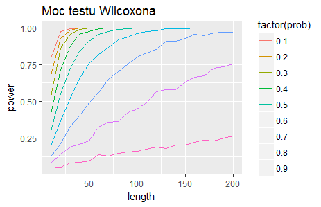

```r
invisible(power_w %>% ggplot(aes(x = length,
                        y = power,
                        col = factor(prob))) +
  geom_line() + ggtitle("Moc testu Wilcoxona"))
knitr::include_graphics("Wilcoxon_p.png")
```

**Liczba obserwacji:** Wraz ze wzrostem liczby obserwacji rośnie moc testu. Sprawdziła się moja hipoteza.  
**Prawdopodobieństwo:** Test Wilcoxona powtórzył rozwiązanie testu Kołmogorowa dla prawdopodobieństwa. Moc testu spada, początkowo nieznacznie, ale wraz ze wzrostem prawdopodobieństwa ten spadek przyśpiesza.  
**Ogólne uwagi:** Spadek mocy w teście Wilcoxona jest bardziej dynamiczny względem spadku w teście Kołmogorowa, następuje to szybciej, lecz wpływ liczby obserwacji jest podobny.

## Wpływ parametru par_2

Rozważę teraz wpływ parametru par_2, czyli lambdy. Prawdopodobieństwo ustawiłem na 0,5.

```r
#############################################################################################
                                            #PAR_2#
#############################################################################################

set.seed(111)
#ilość symulacji
N <- 1

#lambda family_1
lambda_f1 <- 5

#lambda family_2
lambda_f2 <- seq(1,10)

#prawdopodobieństwa wylosowania danych z rozkładu family_1
prob <- 0.5
#poziom istotności
alpha <- 0.05
#długości próby
sample_l <- seq(10,200,by=10)

params <- expand.grid(lambda_f1, lambda_f2, prob, sample_l)
names(params) <- c("lambda_f1", "lambda_f2", "prob", "length")
```

Obliczam moc testu Wilcoxona i dodaję ją do wcześniej utworzonej ramki danych.

```r
powers_w <- sapply(1:nrow(params), function(p){
  lambda_f1 <- params[p, 1]
  lambda_f2 <- params[p, 2]
  prob <- params[p, 3]
  l <- params[p, 4]
  p_sim <-sapply(rep(lambda_f1, N), function(x){
    rmixx <- rmix(l, "poiss", lambda_f1, "poiss", lambda_f2, prob)
    wilcox.test(rmixx, rpois(l,lambda_f1), exact = FALSE)$p.value
 })
 mean(p_sim < alpha)
})
power_w <- bind_cols(params, power = powers_w)
```

Teraz tworzę wykres dla testu.

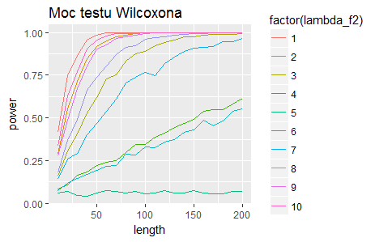

```r
invisible(power_w %>% ggplot(aes(x = length,
                        y = power,
                        col = factor(lambda_f2))) +
  geom_line() + ggtitle("Moc testu Wilcoxona"))
knitr::include_graphics("Wilcoxon_par2.png")
```

**Liczba obserwacji:** Ponownie nie ulega wątpliwości, że wraz ze wzrostem długości próby rośnie moc testu, chociaż wyjątek stanowi par_2 = 5, gdzie moc cały czas oscyluje wokół zera.  
**Prawdopodobieństwo:** Jak to zostało już zaakcentowane przy liczbie obserwacji, w sytuacji, gdy par_1 = par_2, moc testu wynosi trochę więcej niż 0. Im większa jest różnica między par_1 a par_2, tym większa jest moc testu. Linie jednak nie nachodzą na siebie. Kiedy mamy do czynienia z wartościami leżącymi w równej odległości od par_2, ale jedna jest mniejsza, a druga większa, test dla tej mniejszej ma większą moc.  
**Ogólne uwagi:** Najłatwiej jest zauważyć fakt istnienia dwóch rozkładów wtedy, gdy wartość par_2 jest bardziej oddalona od par_1 i jest od niej mniejsza.